# Choose Seq Run 2 Samples

M Fisher

2022-10-21

# Description

Pick samples for the next sequencing run! Maximum = 30 crab stomachs

A reminder of the project goal: > Examine the risk to Dungeness crab instars (age 0+ juveniles) from climate-driven changes in estuarine prey availability.

And a general flowchart for the methods: Describe the current diet of juvenile Dungeness crab -> use existing literature to come up with scenarios of the potential effects of climate change on prey abundance (also, to gather prey energy density info) -> use bioenergetic models to explore the (lack of?) sensitivity of crab instars to climate change impacts on prey availability.

**Table 1.** Sample sizes for each site.

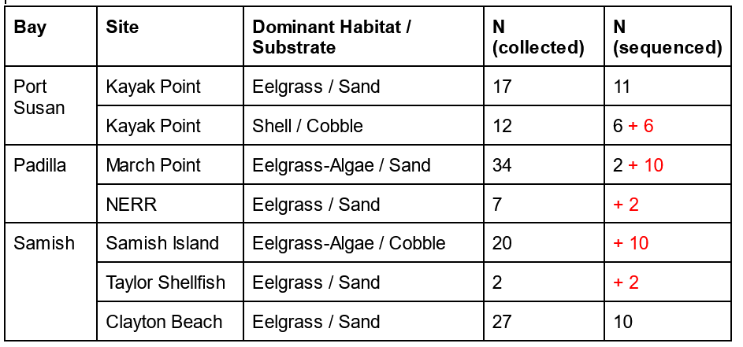

Tentative plan: Variability in prey species among individual crab and between sites are both high. Individual crab tend to have a high degree of species richness, and I didn’t see much “saturation” in the observed species / families either overall or at individual sites. As a result, I would aim for samples which provide even coverage across the three different bays, and if possible, across habitat types within bays. This would provide a broader diet portfolio that is more generally applicable to the northern Puget Sound – maybe resulting in a sensitivity analysis that isn’t potentially specific to the prey available at one site? Especially if juveniles are essentially scavengers of whatever is there.

Alternatively, I could max out the samples that I have at 1-2 sites, and try to reach a point of saturation. This could help me explore the degree to which crab in the same location may diversify their diet, justifying low sensitivity by a willingness to switch prey??

# Site descriptions

*working on it…*

# Preliminary Results

To inform sample choice, look at the following from the run 1 data:

1. $\alpha$ and $\beta$ diversity
2. taxonomic distinctness (vegan doc)[https://search.r-project.org/CRAN/refmans/vegan/html/taxondive.html]
3. species richness per crab
4. nMDS among all samples
5. saturation point for species
6. saturation point for higher taxonomic levels
7. which classes / families are represented at which sites? (just out of curiosity)

For this analysis, I removed any identifications that with too little taxonomic depth (information at family or below is missing). What are the sample sizes for this data set?

```
## # A tibble: 4 x 2
##   Site      `Crab count`
##   <chr>            <int>
## 1 CLAY                10
## 2 KAY                 11
## 3 KAY-shell            6
## 4 MARPT                2
```

## diversity

### $\alpha$

What is the overall species richness at each site?

```
## # A tibble: 4 x 3
##   Site      `crab count` richness
##   <chr>            <int>    <int>
## 1 CLAY                10       50
## 2 KAY                 11       40
## 3 KAY-shell            6       28
## 4 MARPT                2       11
```

### $\beta$

What is the ratio between regional and local species diversity? The greater the similarity in community composition between multiple communities, the lower the value of β-diversity for that set of communities.

```
##           1         2         3
## 2 0.4571429
## 3 0.7173913 0.7750000
## 4 0.8867925 0.9024390 0.7777778
```

```
##           1           2           3           4
##       "KAY" "KAY-shell"      "CLAY"     "MARPT"
```

### distinctness

Taxonomic distinctness = the averaged taxonomic distances among species or individuals in the community (Clarke & Warwick 1998, 2001). In this context, I’ll find the distinctness in prey assemblages between crab (with presence/absence data, both distinctness and diversity reduce to the same index, $\Delta^{+}$, Clarke & Warwick (1998)).

$\Delta^(+)$ per site:

```
##       KAY KAY-shell      CLAY     MARPT
##     96.41     96.26     94.20     90.74
```

Standard deviation of $\Delta^(+)$

```
##       KAY KAY-shell      CLAY     MARPT
##     0.833     1.067     0.721     2.506
```

Some QC graphs for above…

[figure not shown]

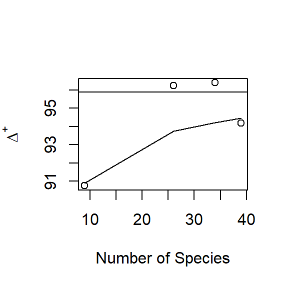

### per crab

What is the distribution of species richness per crab?

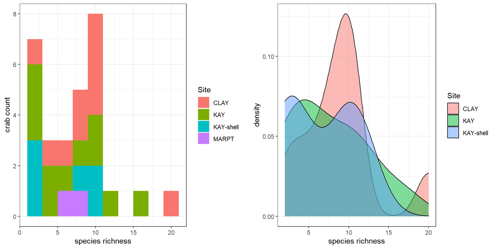

What is the distribution of taxonomic distinctness, per crab?

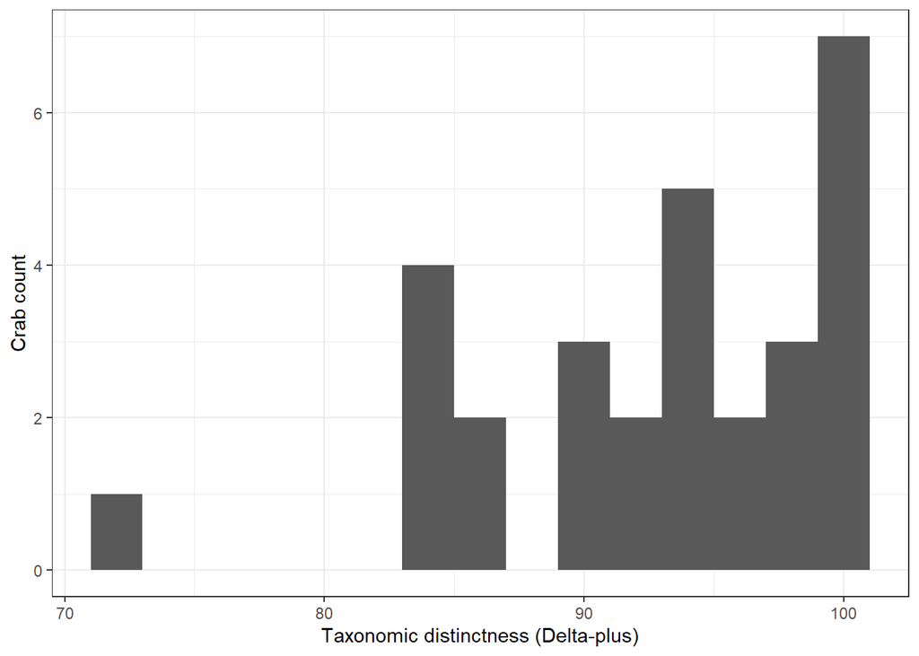

distribution by site.

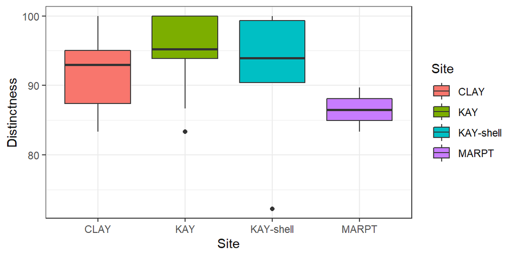

Some QC graphs for above…

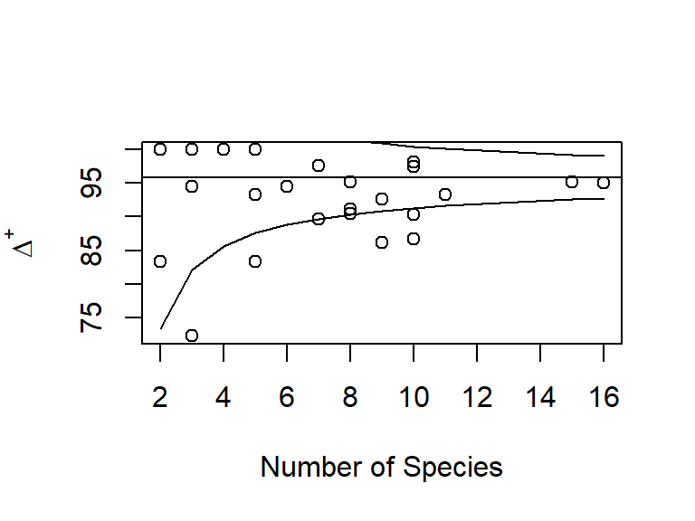

## nMDS

### bray-curtis

Run on a presence/absence matrix.

```r
z <- metaMDS(comm=crab.sp.mat, autotransform=FALSE,distance="bray",k=2,maxit=1000,try=40,trymax=100)
```

```
## *** Solution reached
```

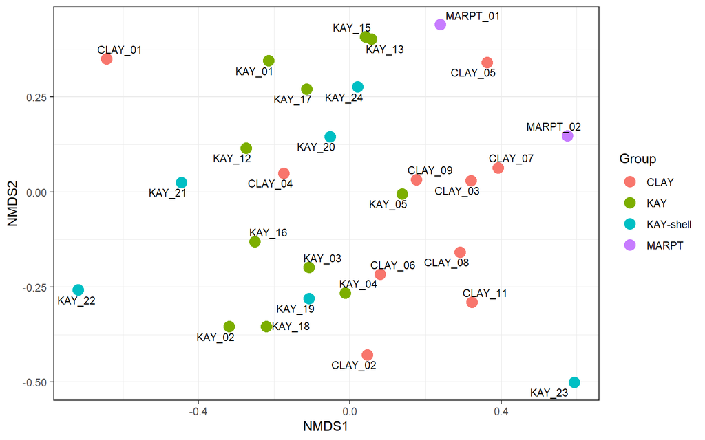

Disclaimer that **the stress is at 0.2, which is potentially misleading**.

Some QC plots for above…

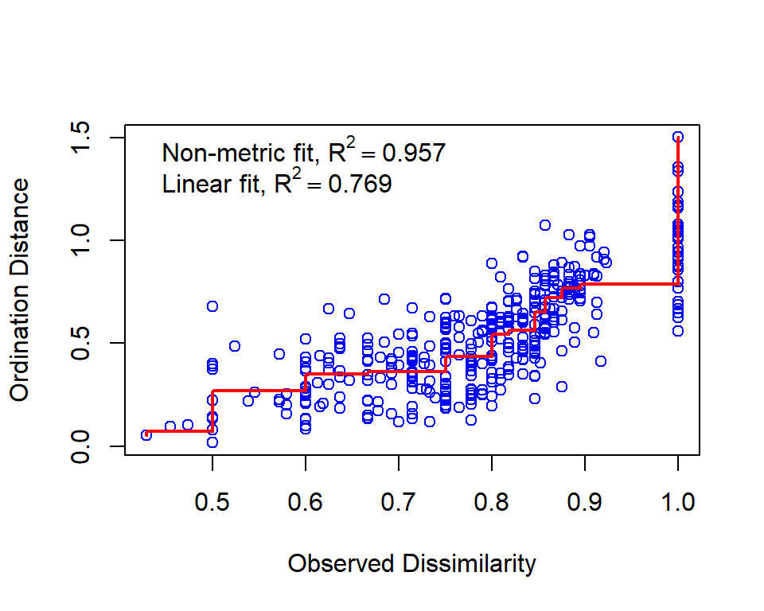

## saturation: species

How many unique species are added per new crab?

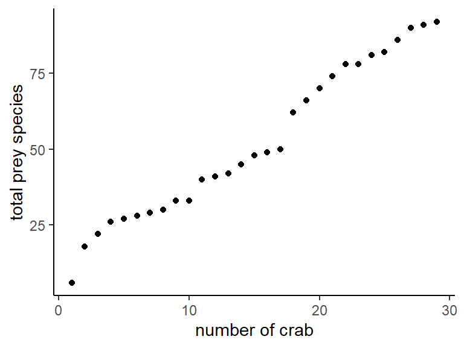

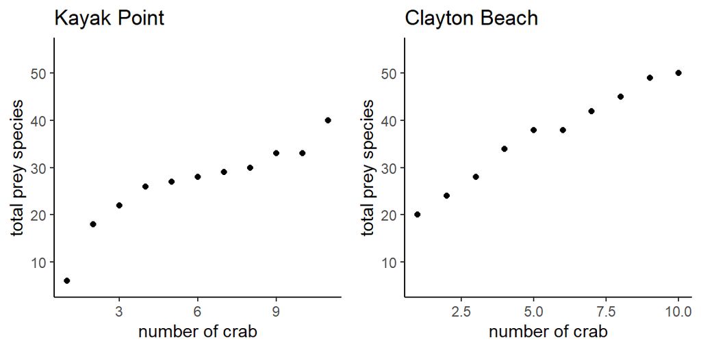

## saturation: higher taxonomy

### Overall

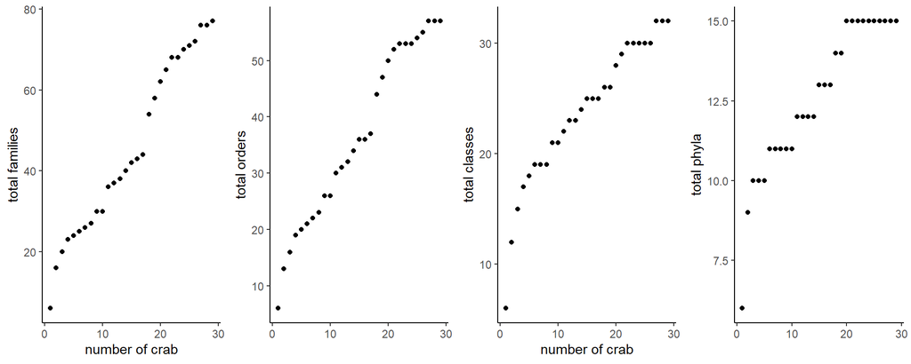

### By site

I just look at orders and phyla here.

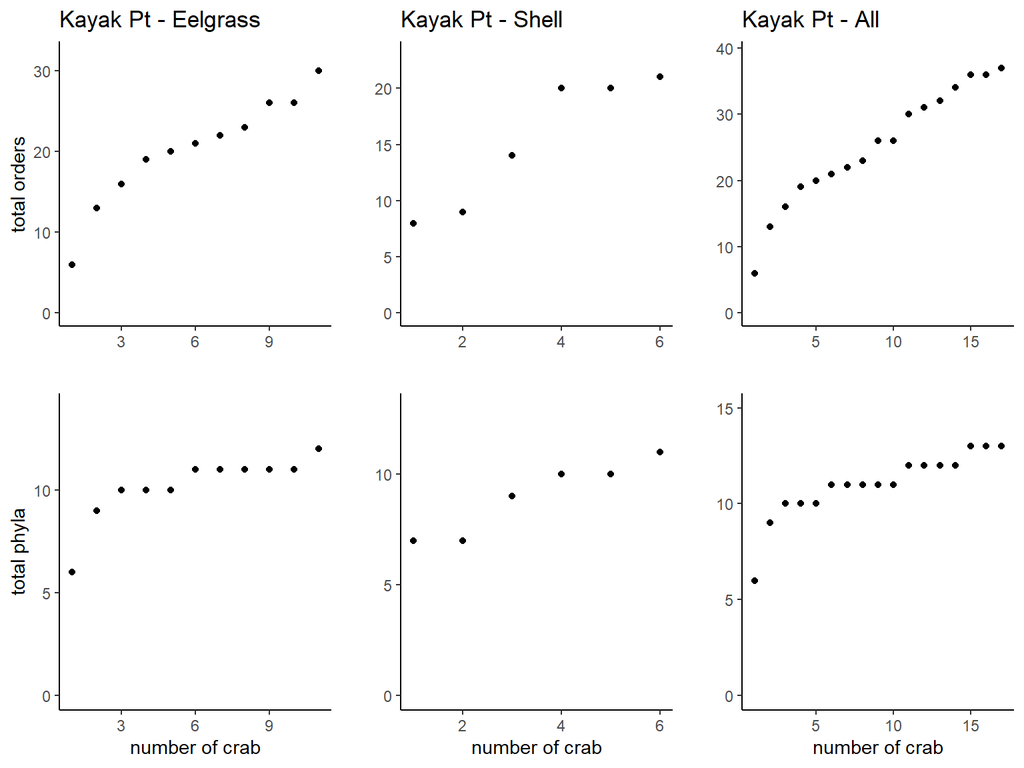

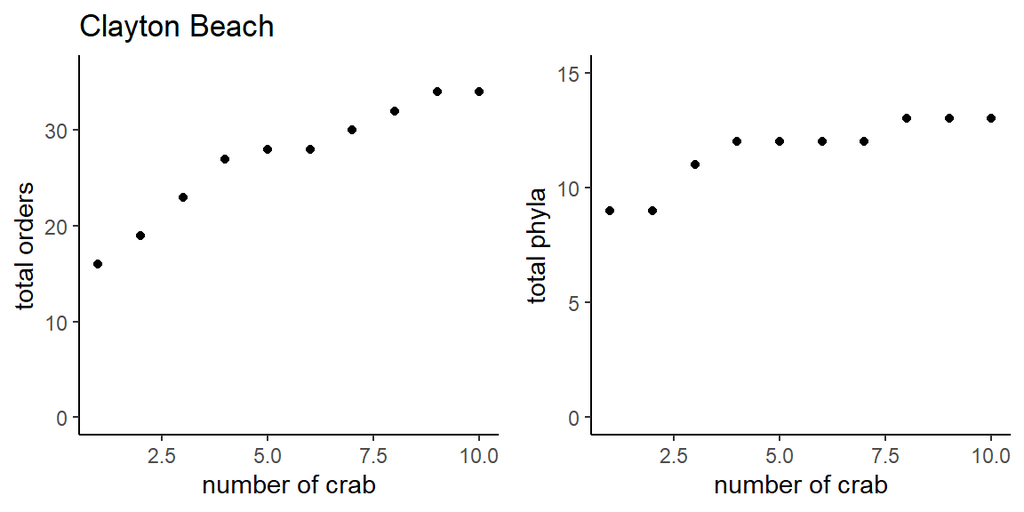

## Prey ID

just for fun…

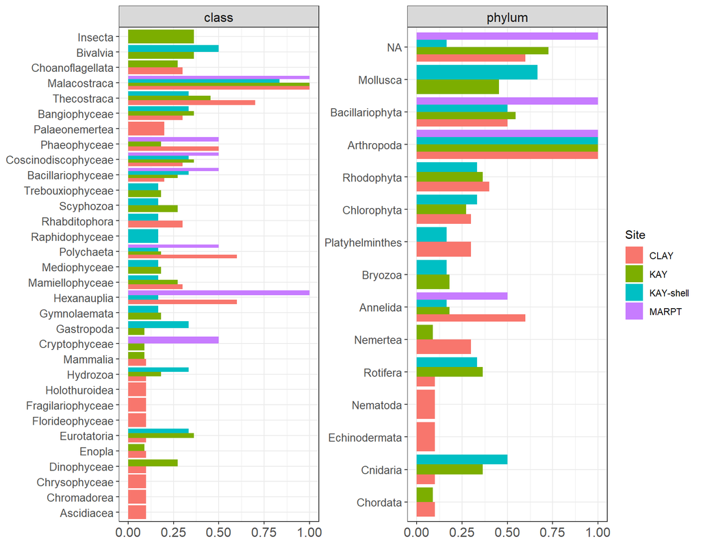

And what were the most common taxa across all sites?

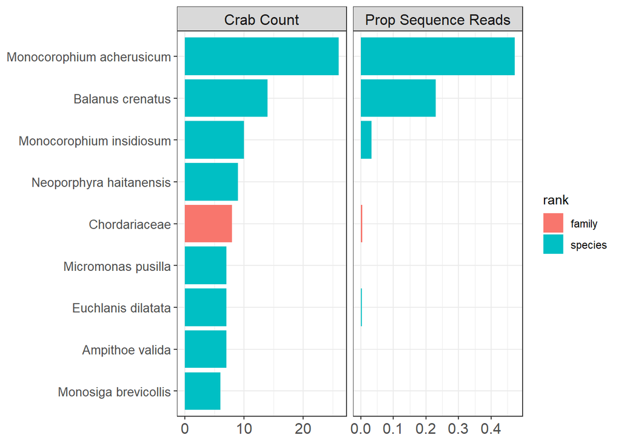